# Midterm 2

Author

Adam Kaderbhai

```r
summer_school <- read_csv("summer_school.csv")
cupid <- read_csv("cupid.csv")
```

# Problem 1 (Exploratory)

```r
summer_school_long <- summer_school %>%
  pivot_longer(cols = starts_with("term"),
               names_to = "terms",
               values_to = "grades") %>%
  filter(!is.na(grades))


summer_school_long %>%
  head() %>%
  gt()
```

| name | gpa | terms | grades |
| --- | --- | --- | --- |
| student_7 | 2.7 | term1 | B |
| student_7 | 2.7 | term2 | F |
| student_24 | 3.7 | term1 | A |
| student_24 | 3.7 | term2 | D |
| student_12 | 2.5 | term1 | B |
| student_20 | 3.3 | term1 | D |

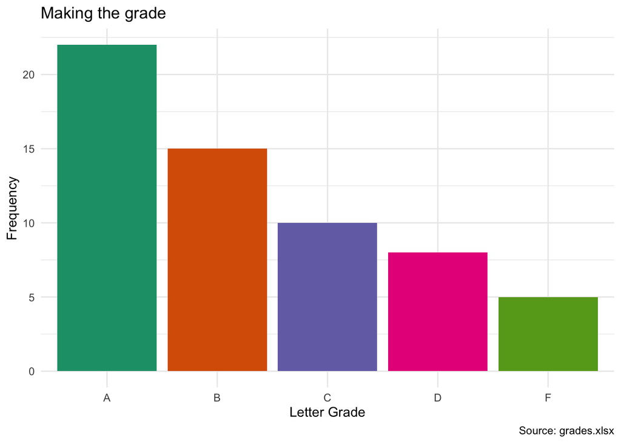

```r
ggplot(summer_school_long, aes(x = grades,
                               fill = grades)) +
  geom_bar(show.legend = FALSE) +

  labs(x = "Letter Grade",
       y = "Frequency",
       title = "Making the grade",
       caption = "Source: grades.xlsx") +

  scale_fill_brewer(palette = "Dark2") +

  theme_minimal()
```

# Problem 2

- $H_o$: The High school’s claim is true
- $H_a$: The High school’s claim is false

```r
t.test(summer_school$gpa, mu = 3.1, df = 39)
```

```
    One Sample t-test

data:  summer_school$gpa
t = -0.91614, df = 39, p-value = 0.3652
alternative hypothesis: true mean is not equal to 3.1
95 percent confidence interval:
 2.859412 3.190588
sample estimates:
mean of x
    3.025
```

The high school’s claim that the average GPA is 3.1 is reasonable. The resulting p-value of 0.365 is high to reject the Null hypothesis. The claimed mean of 3.1 falls within the 95% confidence interval of [2.86, 3.19], suggesting a possible value for the mean GPA for the population.

# Problem 3

```r
terms_summary<- summer_school %>%
  pivot_longer(
    cols = c(term1, term2),
    names_to = "Term",
    values_to = "Grade"
  ) %>%


  filter(!is.na(Grade)) %>%
  group_by(Term) %>%
  summarise(
    Number = n(),
    `DF Rate` = mean(Grade %in% c("D", "F"))
  ) %>%

  mutate(Term = case_when(
    Term == "term1" ~ 1,
    Term == "term2" ~ 2
  ))

  terms_summary %>%
  gt()
```

| Term | Number | DF Rate |
| --- | --- | --- |
| 1 | 40 | 0.10 |
| 2 | 20 | 0.45 |

# Problem 4 (Exploratory)

```r
Top_5_bodytype <- cupid %>%
  filter(!is.na(body_type)) %>%
  group_by(body_type) %>%
  summarize(
    count = n()
  ) %>%

  arrange(desc(count)) %>%
  slice_head(n = 5)

gt(Top_5_bodytype) %>%
  tab_header("Body type by count")
```

Body type by count

| body_type | count |
| --- | --- |
| average | 352 |
| fit | 316 |
| athletic | 293 |
| thin | 129 |
| curvy | 115 |

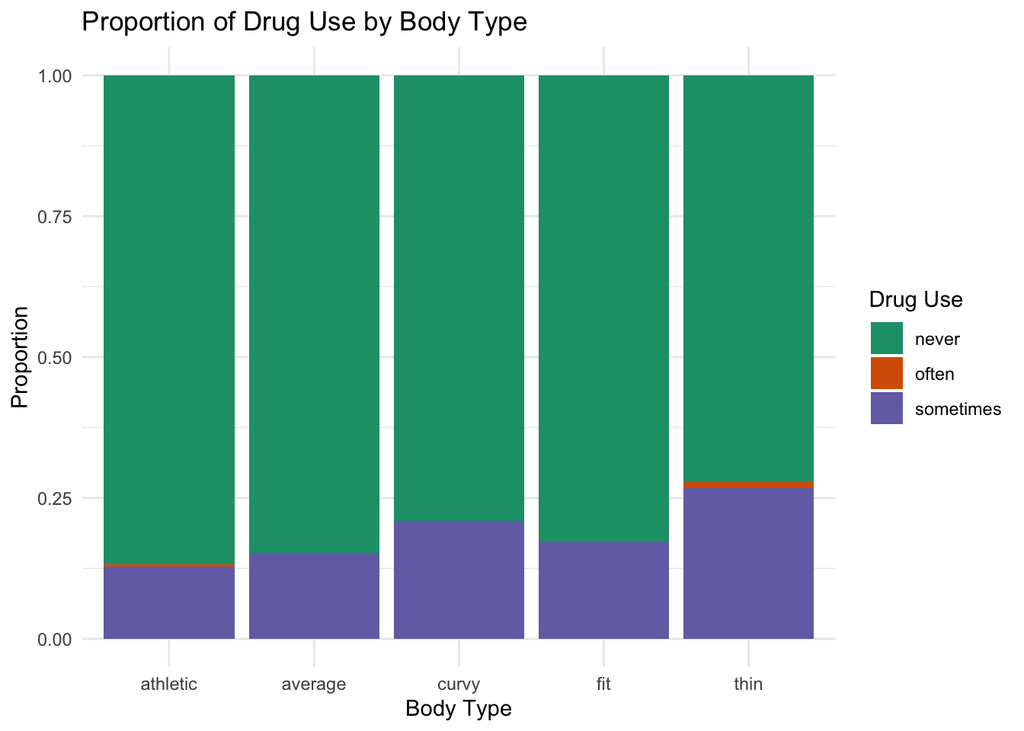

```r
cupid %>%
  filter(body_type %in% Top_5_bodytype$body_type) %>%
  filter(!is.na(drugs)) %>%


ggplot(aes(x = body_type, fill = drugs)) +
  geom_bar(position = "fill") +
  scale_fill_brewer(palette = "Dark2") +
  labs(
    title = "Proportion of Drug Use by Body Type",
    x = "Body Type",
    y = "Proportion",
    fill = "Drug Use"
  ) +
  theme_minimal()
```

From the graph, drug usage does appear to vary across the different body type groups. For example, the proportion of `sometimes` users is visibly larger for the `curvy` and `thin` body types compared to the `athletic` and `fit` and `average` types. However, because the `never` category is dominant for all groups, the differences in drug use, while present, are not dramatic. Without a formal statistical test, we can only describe these variations and cannot conclude if they represent a significant, real-world relationship or are simply due to chance within this specific sample.

# Problem 5 (Inferential)

- $H_o$: Gallup’s claim is true
- $H_a$: Gallup’s claim is false

```r
Observed_Orientation_by_count <- cupid %>%
  group_by(orientation) %>%
  summarize(
    count = n()
  )

gt(Observed_Orientation_by_count) %>%
  tab_header("Orientation by count")
```

Orientation by count

| orientation | count |
| --- | --- |
| bisexual | 80 |
| gay | 138 |
| straight | 1255 |

```r
Observed <- c(138, 80, 1255)

Probs <- c(0.034, 0.052, 0.914)



chisq.test(Observed, p = Probs)
```

```
    Chi-squared test for given probabilities

data:  Observed
X-squared = 160.68, df = 2, p-value < 2.2e-16
```

The claim that the cupid dataset is consistent with Gallup’s national poll data is not reasonable. The resulting p-value of less than `2.2e-16` is extremely low, providing evidence to reject the `null hypothesis` that the distributions are the same. This significant difference indicates that the proportions of sexual orientations in the OkCupid dataset are not representative of the general U.S. adult population.

# Problem 6 (Exploratory)

```r
individual_ethnicities <- cupid %>%
  select(ethnicity) %>%
  filter(!is.na(ethnicity)) %>%
  separate_rows(ethnicity, sep = ",")



top_6_ethnicities <- individual_ethnicities %>%
  filter(!is.na(ethnicity)) %>%
  group_by(ethnicity) %>%
  summarize(
    count = n()
  ) %>%

  arrange(desc(count)) %>%
  slice_head(n = 6)

gt(top_6_ethnicities)
```

| ethnicity | count |
| --- | --- |
| white | 800 |
| asian | 223 |
| white | 118 |
| hispanic / latin | 110 |
| black | 71 |
| other | 49 |

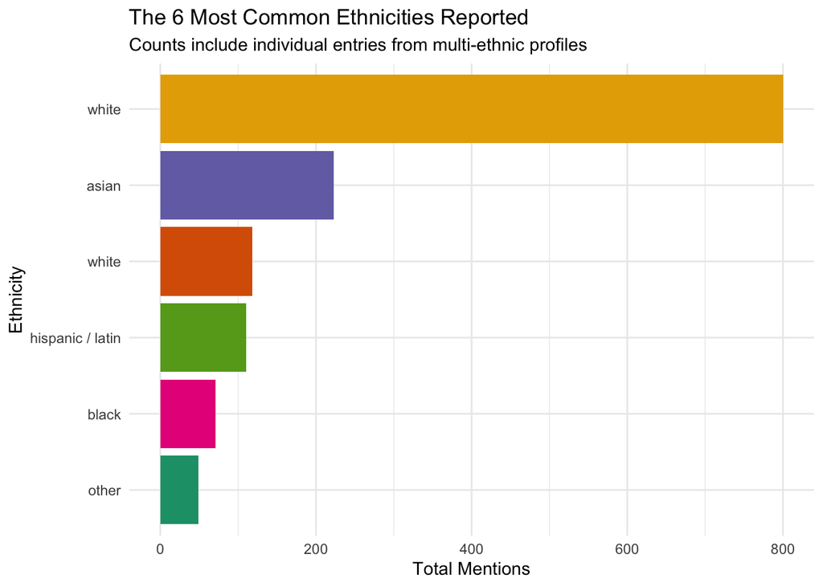

```r
ggplot(top_6_ethnicities, aes(x = fct_reorder(ethnicity, count), y = count)) +
  geom_col(aes(fill = ethnicity), show.legend = FALSE) +
  coord_flip() +
  labs(
    title = "The 6 Most Common Ethnicities Reported",
    subtitle = "Counts include individual entries from multi-ethnic profiles",
    x = "Ethnicity",
    y = "Total Mentions"
  ) +

  scale_fill_brewer(palette = "Dark2") +
  theme_minimal()
```